# Project7 - Prosper Loan Data Exploration

### by Lucas Aledi

- 1. Introduction - Prosper: advancing financial well-being
- 2. Data Wrangling
  - 2.1. Gathering Data
  - 2.2. Assessing Data
  - 2.3. Cleaning Data
- 3. Exploratory Data Analysis (EDA)
  - 3.1. LoanOriginalAmount
    - 3.1.1. What the distribution of number of loans issued and their amount looks like?
    - 3.1.2. How the LoanOriginalAmount and the MonthlyLoanPayment distributions looks like?
    - 3.1.3. What the relationship between those 3 most common loan amounts and montlhy installment payments would look like?
    - 3.1.4. What the relationship between LoanOriginalAmount and MonthlyLoanPayment would look like?
    - 3.1.5. Does the term of a loan influence the size of its monthly payments?
  - 3.2. LoanStatus
    - 3.2.1. How EmploymentStatusDuration, DebtToIncomeRatio, BankcardUtilization, IncomeRange are related to different LoanStatus?
    - 3.2.2. How IncomeRange is related to different LoanStatus?
    - 3.2.3. How LoanOriginalAmount and BorrowerAPR are related to different LoanStatus?
    - 3.2.4. How BorrowerAPR is related to different LoanStatus?
- 4. Conclusions
- 5. References

## 1. Introduction - Prosper: advancing financial well-being

[Prosper](https://www.prosper.com) was founded in 2005 as the first peer-to-peer lending marketplace in the United States. Since then, Prosper has facilitated more than $18 billion in loans to more than 1,060,000 people.

This time, we have been asked to analyze a dataset containing 113,937 loans with 81 variables on each loan, the original dataset provides in-depth information such as loan amount, borrower's APR and interest-rate, as well as Prosper's rating, current loan status, borrower income, and many others.

```python
## import all packages and set plots to be embedded inline
import os
import requests
from sqlalchemy import create_engine
import pandas as pd
import numpy as np
import matplotlib.pyplot as plt
import seaborn as sb

%matplotlib inline
```

back to top

## 2. Data Wrangling

### 2.1. Gathering Data

Let's start by downloading the relevant dataset. The file (*prosperLoanData.csv*) is hosted on Udacity's servers and can be downloaded programmatically using the [requests library](https://requests.readthedocs.io/en/master/#requests-http-for-humans) and [this URL](https://s3.amazonaws.com/udacity-hosted-downloads/ud651/prosperLoanData.csv).

```python
## create folder if not existent
## wrangle_act.ipynb is on the same folder as the .tsv file
folder_name= './'
if not os.path.exists(folder_name):
    os.makedirs(folder_name)

## request http
url= 'https://s3.amazonaws.com/udacity-hosted-downloads/ud651/prosperLoanData.csv'
response= requests.get(url)
```

```python
## test
response
```

```
<Response [200]>
```

```python
## saving archive into file handle
with open(os.path.join(folder_name,
                       url.split('/')[-1]), # splits URL & selects the last item
                       mode='wb') as file:  # response.content is bytes not text, so mode='wb'
    file.write(response.content)            # write to file handle
```

```python
## test
os.listdir()
```

```
['prosper_data_slide.ipynb',
 '.DS_Store',
 'ProsperData.db',
 'prosperLoanData.csv',
 'prosper_loan_data_exploration.ipynb',
 'readme.md',
 '.ipynb_checkpoints',
 'ProsperData_clean.csv']
```

```python
## load dataset into pandas dataframe
df= pd.read_csv('prosperLoanData.csv')
```

```python
## test
print(df.info())
df.sample(n=10, random_state= 2021)
```

```
<class 'pandas.core.frame.DataFrame'>
RangeIndex: 113937 entries, 0 to 113936
Data columns (total 81 columns):
 #   Column                               Non-Null Count   Dtype
---  ------                               --------------   -----
 0   ListingKey                           113937 non-null  object
 1   ListingNumber                        113937 non-null  int64
 2   ListingCreationDate                  113937 non-null  object
 3   CreditGrade                          28953 non-null   object
 4   Term                                 113937 non-null  int64
 5   LoanStatus                           113937 non-null  object
 6   ClosedDate                           55089 non-null   object
 7   BorrowerAPR                          113912 non-null  float64
 8   BorrowerRate                         113937 non-null  float64
 9   LenderYield                          113937 non-null  float64
```

[output cut: 74 more lines]

|  | ListingKey | ListingNumber | ListingCreationDate | CreditGrade | Term | LoanStatus | ClosedDate | BorrowerAPR | BorrowerRate | LenderYield | ... | LP_ServiceFees | LP_CollectionFees | LP_GrossPrincipalLoss | LP_NetPrincipalLoss | LP_NonPrincipalRecoverypayments | PercentFunded | Recommendations | InvestmentFromFriendsCount | InvestmentFromFriendsAmount | Investors |
| --- | --- | --- | --- | --- | --- | --- | --- | --- | --- | --- | --- | --- | --- | --- | --- | --- | --- | --- | --- | --- | --- |
| 96777 | BEDD35675961998143CAD1B | 690670 | 2012-12-25 21:21:33.347000000 | NaN | 60 | Current | NaN | 0.28160 | 0.2557 | 0.2457 | ... | -109.31 | 0.0 | 0.0 | 0.0 | 0.0 | 1.0 | 0 | 0 | 0.0 | 111 |
| 82442 | AD8B3572780866025DEDBCD | 731728 | 2013-03-17 12:07:03.730000000 | NaN | 60 | Current | NaN | 0.23872 | 0.2139 | 0.2039 | ... | -131.38 | 0.0 | 0.0 | 0.0 | 0.0 | 1.0 | 0 | 0 | 0.0 | 3 |
| 62421 | FEEC355338890860703509E | 611643 | 2012-07-14 13:37:10.310000000 | NaN | 60 | Past Due (61-90 days) | NaN | 0.27462 | 0.2489 | 0.2389 | ... | -86.85 | 0.0 | 0.0 | 0.0 | 0.0 | 1.0 | 0 | 0 | 0.0 | 89 |
| 27260 | 3002340991969375716BCC8 | 260336 | 2008-01-05 08:45:21.393000000 | D | 36 | Completed | 2011-01-11 00:00:00 | 0.37453 | 0.3500 | 0.3400 | ... | -55.94 | 0.0 | 0.0 | 0.0 | 0.0 | 1.0 | 0 | 0 | 0.0 | 43 |
| 72929 | CAA035429173176024FBC61 | 570813 | 2012-03-21 08:25:13.790000000 | NaN | 36 | Completed | 2014-02-03 00:00:00 | 0.35797 | 0.3177 | 0.3077 | ... | -58.31 | 0.0 | 0.0 | 0.0 | 0.0 | 1.0 | 0 | 0 | 0.0 | 10 |
| 16454 | 1ACF3596028772925EE48F7 | 1040857 | 2013-12-09 14:11:16.973000000 | NaN | 36 | Current | NaN | 0.06726 | 0.0605 | 0.0505 | ... | -16.61 | 0.0 | 0.0 | 0.0 | 0.0 | 1.0 | 0 | 0 | 0.0 | 1 |
| 20961 | BD713493803147758662014 | 475059 | 2010-09-10 08:45:36.500000000 | NaN | 36 | Completed | 2012-12-20 00:00:00 | 0.13271 | 0.1115 | 0.1015 | ... | -90.51 | 0.0 | 0.0 | 0.0 | 0.0 | 1.0 | 0 | 0 | 0.0 | 149 |
| 76062 | 456E3367639156096AF8394 | 39447 | 2006-09-14 12:46:50.160000000 | C | 36 | Completed | 2008-05-20 00:00:00 | 0.14960 | 0.1425 | 0.1375 | ... | -87.28 | 0.0 | 0.0 | 0.0 | 0.0 | 1.0 | 0 | 0 | 0.0 | 302 |
| 105357 | D19E3539518419549C45649 | 562862 | 2012-02-26 18:58:21.540000000 | NaN | 36 | Completed | 2013-04-15 00:00:00 | 0.17359 | 0.1449 | 0.1349 | ... | -143.77 | 0.0 | 0.0 | 0.0 | 0.0 | 1.0 | 0 | 0 | 0.0 | 7 |
| 82582 | 1FB1358129074666072703D | 796201 | 2013-06-03 17:48:37.377000000 | NaN | 36 | Current | NaN | 0.28780 | 0.2492 | 0.2392 | ... | -24.99 | 0.0 | 0.0 | 0.0 | 0.0 | 1.0 | 0 | 0 | 0.0 | 70 |

10 rows × 81 columns

back to top

## 2.2. Assessing Data

Having the data loaded, now let's visually and programmatically assess its attributes, see how it is structured and, finally enumerate quality and tidiness issues that may exist.

```python
## overview of data shape and composition
df.info()
```

```
<class 'pandas.core.frame.DataFrame'>
RangeIndex: 113937 entries, 0 to 113936
Data columns (total 81 columns):
 #   Column                               Non-Null Count   Dtype
---  ------                               --------------   -----
 0   ListingKey                           113937 non-null  object
 1   ListingNumber                        113937 non-null  int64
 2   ListingCreationDate                  113937 non-null  object
 3   CreditGrade                          28953 non-null   object
 4   Term                                 113937 non-null  int64
 5   LoanStatus                           113937 non-null  object
 6   ClosedDate                           55089 non-null   object
 7   BorrowerAPR                          113912 non-null  float64
 8   BorrowerRate                         113937 non-null  float64
 9   LenderYield                          113937 non-null  float64
```

[output cut: 73 more lines]

```python
## overview of data shape and composition
df.iloc[:, :20].sample(n=5, random_state=2021)
```

|  | ListingKey | ListingNumber | ListingCreationDate | CreditGrade | Term | LoanStatus | ClosedDate | BorrowerAPR | BorrowerRate | LenderYield | EstimatedEffectiveYield | EstimatedLoss | EstimatedReturn | ProsperRating (numeric) | ProsperRating (Alpha) | ProsperScore | ListingCategory (numeric) | BorrowerState | Occupation | EmploymentStatus |
| --- | --- | --- | --- | --- | --- | --- | --- | --- | --- | --- | --- | --- | --- | --- | --- | --- | --- | --- | --- | --- |
| 96777 | BEDD35675961998143CAD1B | 690670 | 2012-12-25 21:21:33.347000000 | NaN | 60 | Current | NaN | 0.28160 | 0.2557 | 0.2457 | 0.2263 | 0.0975 | 0.1288 | 3.0 | D | 4.0 | 8 | NC | Analyst | Employed |
| 82442 | AD8B3572780866025DEDBCD | 731728 | 2013-03-17 12:07:03.730000000 | NaN | 60 | Current | NaN | 0.23872 | 0.2139 | 0.2039 | 0.1898 | 0.0774 | 0.1124 | 4.0 | C | 7.0 | 1 | TX | Other | Employed |
| 62421 | FEEC355338890860703509E | 611643 | 2012-07-14 13:37:10.310000000 | NaN | 60 | Past Due (61-90 days) | NaN | 0.27462 | 0.2489 | 0.2389 | 0.2332 | 0.0890 | 0.1442 | 4.0 | C | 7.0 | 2 | WA | Retail Management | Employed |
| 27260 | 3002340991969375716BCC8 | 260336 | 2008-01-05 08:45:21.393000000 | D | 36 | Completed | 2011-01-11 00:00:00 | 0.37453 | 0.3500 | 0.3400 | NaN | NaN | NaN | NaN | NaN | NaN | 4 | GA | Civil Service | Full-time |
| 72929 | CAA035429173176024FBC61 | 570813 | 2012-03-21 08:25:13.790000000 | NaN | 36 | Completed | 2014-02-03 00:00:00 | 0.35797 | 0.3177 | 0.3077 | 0.2896 | 0.1650 | 0.1246 | 1.0 | HR | 4.0 | 3 | PA | Retail Management | Employed |

```python
## overview of data shape and composition
df.iloc[:, 20:40].sample(n=5, random_state=2021)
```

|  | EmploymentStatusDuration | IsBorrowerHomeowner | CurrentlyInGroup | GroupKey | DateCreditPulled | CreditScoreRangeLower | CreditScoreRangeUpper | FirstRecordedCreditLine | CurrentCreditLines | OpenCreditLines | TotalCreditLinespast7years | OpenRevolvingAccounts | OpenRevolvingMonthlyPayment | InquiriesLast6Months | TotalInquiries | CurrentDelinquencies | AmountDelinquent | DelinquenciesLast7Years | PublicRecordsLast10Years | PublicRecordsLast12Months |
| --- | --- | --- | --- | --- | --- | --- | --- | --- | --- | --- | --- | --- | --- | --- | --- | --- | --- | --- | --- | --- |
| 96777 | 2.0 | True | False | NaN | 2012-12-25 21:21:31 | 680.0 | 699.0 | 1989-01-01 00:00:00 | 11.0 | 11.0 | 19.0 | 3 | 75.0 | 2.0 | 5.0 | 1.0 | 98.0 | 11.0 | 1.0 | 0.0 |
| 82442 | 128.0 | True | False | NaN | 2013-03-17 12:07:01 | 680.0 | 699.0 | 2001-03-02 00:00:00 | 11.0 | 9.0 | 27.0 | 7 | 744.0 | 0.0 | 1.0 | 0.0 | 0.0 | 2.0 | 0.0 | 0.0 |
| 62421 | 174.0 | True | False | NaN | 2012-07-14 13:37:06 | 680.0 | 699.0 | 1999-05-04 00:00:00 | 12.0 | 12.0 | 23.0 | 10 | 341.0 | 1.0 | 12.0 | 0.0 | 0.0 | 0.0 | 1.0 | 0.0 |
| 27260 | 225.0 | False | False | NaN | 2007-12-20 15:12:38.140000000 | 600.0 | 619.0 | 1986-11-17 00:00:00 | 5.0 | 3.0 | 11.0 | 3 | 245.0 | 2.0 | 5.0 | 2.0 | 0.0 | 33.0 | 1.0 | 1.0 |
| 72929 | 43.0 | True | False | NaN | 2012-03-21 08:25:08 | 700.0 | 719.0 | 1999-01-19 00:00:00 | 5.0 | 5.0 | 19.0 | 3 | 86.0 | 0.0 | 1.0 | 0.0 | 0.0 | 2.0 | 0.0 | 0.0 |

```python
## overview of data shape and composition
df.iloc[:, 40:60].sample(n=5, random_state=2021)
```

|  | RevolvingCreditBalance | BankcardUtilization | AvailableBankcardCredit | TotalTrades | TradesNeverDelinquent (percentage) | TradesOpenedLast6Months | DebtToIncomeRatio | IncomeRange | IncomeVerifiable | StatedMonthlyIncome | LoanKey | TotalProsperLoans | TotalProsperPaymentsBilled | OnTimeProsperPayments | ProsperPaymentsLessThanOneMonthLate | ProsperPaymentsOneMonthPlusLate | ProsperPrincipalBorrowed | ProsperPrincipalOutstanding | ScorexChangeAtTimeOfListing | LoanCurrentDaysDelinquent |
| --- | --- | --- | --- | --- | --- | --- | --- | --- | --- | --- | --- | --- | --- | --- | --- | --- | --- | --- | --- | --- |
| 96777 | 2373.0 | 0.56 | 923.0 | 17.0 | 0.77 | 2.0 | 0.12 | $75,000-99,999 | True | 7500.000000 | 5B6336702887838954C6B9C | NaN | NaN | NaN | NaN | NaN | NaN | NaN | NaN | 0 |
| 82442 | 37557.0 | 0.82 | 7164.0 | 27.0 | 0.96 | 1.0 | 0.18 | $75,000-99,999 | True | 7083.333333 | AA2F367890710522239A6B6 | NaN | NaN | NaN | NaN | NaN | NaN | NaN | NaN | 0 |
| 62421 | 6020.0 | 0.48 | 6117.0 | 21.0 | 1.00 | 1.0 | 0.14 | $75,000-99,999 | True | 7916.666667 | A2AF3657042069205F72885 | NaN | NaN | NaN | NaN | NaN | NaN | NaN | NaN | 77 |
| 27260 | 4246.0 | 0.93 | 304.0 | 9.0 | 0.55 | 3.0 | 0.07 | $50,000-74,999 | True | 5445.583333 | 4A9F341095199727041F37E | NaN | NaN | NaN | NaN | NaN | NaN | NaN | NaN | 0 |
| 72929 | 3282.0 | 0.54 | 2708.0 | 17.0 | 0.55 | 0.0 | 0.29 | $25,000-49,999 | True | 2166.666667 | 9D233646122827766F54199 | NaN | NaN | NaN | NaN | NaN | NaN | NaN | NaN | 0 |

```python
## overview of data shape and composition
df.iloc[:, 60:].sample(n=5, random_state=2021)
```

|  | LoanFirstDefaultedCycleNumber | LoanMonthsSinceOrigination | LoanNumber | LoanOriginalAmount | LoanOriginationDate | LoanOriginationQuarter | MemberKey | MonthlyLoanPayment | LP_CustomerPayments | LP_CustomerPrincipalPayments | ... | LP_ServiceFees | LP_CollectionFees | LP_GrossPrincipalLoss | LP_NetPrincipalLoss | LP_NonPrincipalRecoverypayments | PercentFunded | Recommendations | InvestmentFromFriendsCount | InvestmentFromFriendsAmount | Investors |
| --- | --- | --- | --- | --- | --- | --- | --- | --- | --- | --- | --- | --- | --- | --- | --- | --- | --- | --- | --- | --- | --- |
| 96777 | NaN | 14 | 80723 | 10000 | 2013-01-04 00:00:00 | Q1 2013 | 445835673824435931319FC | 296.86 | 4156.04 | 1354.29 | ... | -109.31 | 0.0 | 0.0 | 0.0 | 0.0 | 1.0 | 0 | 0 | 0.0 | 111 |
| 82442 | NaN | 12 | 87099 | 15000 | 2013-03-29 00:00:00 | Q1 2013 | 660D3573018067258D21347 | 409.10 | 4500.10 | 1681.39 | ... | -131.38 | 0.0 | 0.0 | 0.0 | 0.0 | 1.0 | 0 | 0 | 0.0 | 3 |
| 62421 | NaN | 20 | 71005 | 7000 | 2012-07-23 00:00:00 | Q3 2012 | 9B0635518017719398F9F27 | 205.01 | 3280.16 | 1118.23 | ... | -86.85 | 0.0 | 0.0 | 0.0 | 0.0 | 1.0 | 0 | 0 | 0.0 | 89 |
| 27260 | NaN | 74 | 25242 | 3100 | 2008-01-11 00:00:00 | Q1 2008 | 00E0339261860563081B5E5 | 116.20 | 5057.31 | 3099.99 | ... | -55.94 | 0.0 | 0.0 | 0.0 | 0.0 | 1.0 | 0 | 0 | 0.0 | 43 |
| 72929 | NaN | 24 | 62443 | 4000 | 2012-03-26 00:00:00 | Q1 2012 | 1FBB35429760737526443C0 | 173.71 | 5853.19 | 4000.00 | ... | -58.31 | 0.0 | 0.0 | 0.0 | 0.0 | 1.0 | 0 | 0 | 0.0 | 10 |

5 rows × 21 columns

```python
## overview of data shape and composition
df.describe()
```

|  | ListingNumber | Term | BorrowerAPR | BorrowerRate | LenderYield | EstimatedEffectiveYield | EstimatedLoss | EstimatedReturn | ProsperRating (numeric) | ProsperScore | ... | LP_ServiceFees | LP_CollectionFees | LP_GrossPrincipalLoss | LP_NetPrincipalLoss | LP_NonPrincipalRecoverypayments | PercentFunded | Recommendations | InvestmentFromFriendsCount | InvestmentFromFriendsAmount | Investors |
| --- | --- | --- | --- | --- | --- | --- | --- | --- | --- | --- | --- | --- | --- | --- | --- | --- | --- | --- | --- | --- | --- |
| count | 1.139370e+05 | 113937.000000 | 113912.000000 | 113937.000000 | 113937.000000 | 84853.000000 | 84853.000000 | 84853.000000 | 84853.000000 | 84853.000000 | ... | 113937.000000 | 113937.000000 | 113937.000000 | 113937.000000 | 113937.000000 | 113937.000000 | 113937.000000 | 113937.000000 | 113937.000000 | 113937.000000 |
| mean | 6.278857e+05 | 40.830248 | 0.218828 | 0.192764 | 0.182701 | 0.168661 | 0.080306 | 0.096068 | 4.072243 | 5.950067 | ... | -54.725641 | -14.242698 | 700.446342 | 681.420499 | 25.142686 | 0.998584 | 0.048027 | 0.023460 | 16.550751 | 80.475228 |
| std | 3.280762e+05 | 10.436212 | 0.080364 | 0.074818 | 0.074516 | 0.068467 | 0.046764 | 0.030403 | 1.673227 | 2.376501 | ... | 60.675425 | 109.232758 | 2388.513831 | 2357.167068 | 275.657937 | 0.017919 | 0.332353 | 0.232412 | 294.545422 | 103.239020 |
| min | 4.000000e+00 | 12.000000 | 0.006530 | 0.000000 | -0.010000 | -0.182700 | 0.004900 | -0.182700 | 1.000000 | 1.000000 | ... | -664.870000 | -9274.750000 | -94.200000 | -954.550000 | 0.000000 | 0.700000 | 0.000000 | 0.000000 | 0.000000 | 1.000000 |
| 25% | 4.009190e+05 | 36.000000 | 0.156290 | 0.134000 | 0.124200 | 0.115670 | 0.042400 | 0.074080 | 3.000000 | 4.000000 | ... | -73.180000 | 0.000000 | 0.000000 | 0.000000 | 0.000000 | 1.000000 | 0.000000 | 0.000000 | 0.000000 | 2.000000 |
| 50% | 6.005540e+05 | 36.000000 | 0.209760 | 0.184000 | 0.173000 | 0.161500 | 0.072400 | 0.091700 | 4.000000 | 6.000000 | ... | -34.440000 | 0.000000 | 0.000000 | 0.000000 | 0.000000 | 1.000000 | 0.000000 | 0.000000 | 0.000000 | 44.000000 |
| 75% | 8.926340e+05 | 36.000000 | 0.283810 | 0.250000 | 0.240000 | 0.224300 | 0.112000 | 0.116600 | 5.000000 | 8.000000 | ... | -13.920000 | 0.000000 | 0.000000 | 0.000000 | 0.000000 | 1.000000 | 0.000000 | 0.000000 | 0.000000 | 115.000000 |
| max | 1.255725e+06 | 60.000000 | 0.512290 | 0.497500 | 0.492500 | 0.319900 | 0.366000 | 0.283700 | 7.000000 | 11.000000 | ... | 32.060000 | 0.000000 | 25000.000000 | 25000.000000 | 21117.900000 | 1.012500 | 39.000000 | 33.000000 | 25000.000000 | 1189.000000 |

8 rows × 61 columns

Having taken a quick look at the data, we can now list the following issues that deserve some attention:

#### Tidiness issues

- 1. Choose subset of important features
- 2. Merge CreditGrade (before 2009) and ProsperRating(Alpha) (after 2009) and drop other irrelevant columns
- 3. Fill in missing values of Occupation ('unknown')
- 4. Convert CreditScoreRangeLower and CreditScoreRangeUpper into a single CreditScore value (calculate average of the two variables)

#### Quality issues

- 5. Remove rows with null on DebtToIncomeRatio
- 6. ListingCreationDate and ClosedDate should be datetime
- 7. ListingCategory, BorrowerState, Occupation, EmploymentStatus (not ordered), Term, IncomeRange and ProsperRating (ordered) should be categorical

  ```
    * Remove any null rows on the columns above
  ```

- 8. Remove null rows on EstimatedEffectiveYield
- 9. Create 'quarter' column
- 10. Rows with MonthlyLoanPayment, EmploymentStatusDuration equal 0 shoul be np.nan

back to top

## 2.3. Cleaning Data

Before getting started, we shall make a copy of the dataframe.

```python
## Before starting the cleaning process, make a copy of the dataframe
df_clean= df.copy()
```

Back to tidiness issues

### Tidiness issues

**1) Choosing subset of importatn features**

Define:

- Given the large number of columns, we need to focus on those which can be interesting to us;
- Select columns and attribute to 'df' new value/dataframe containing only relevant columns.

```python
## Subset the dataframe by selecting interesting features
cols= ['ListingNumber', 'ListingCreationDate', 'LoanOriginationQuarter', 'LoanStatus', 'ClosedDate', 'Term', 'LoanOriginalAmount', 'MonthlyLoanPayment',
       'BorrowerState', 'Occupation', 'EmploymentStatus', 'EmploymentStatusDuration', 'IncomeRange',
       'ListingCategory (numeric)', 'BorrowerAPR', 'EstimatedEffectiveYield', 'CreditGrade', 'ProsperRating (Alpha)',
       'ProsperScore', 'CreditScoreRangeLower', 'CreditScoreRangeUpper', 'BankcardUtilization', 'TradesNeverDelinquent (percentage)',
       'DebtToIncomeRatio', 'TotalProsperLoans', 'LoanFirstDefaultedCycleNumber', 'Investors']

df_clean= df_clean[cols]
```

```python
## test
df_clean.info()
```

```
<class 'pandas.core.frame.DataFrame'>
RangeIndex: 113937 entries, 0 to 113936
Data columns (total 27 columns):
 #   Column                              Non-Null Count   Dtype
---  ------                              --------------   -----
 0   ListingNumber                       113937 non-null  int64
 1   ListingCreationDate                 113937 non-null  object
 2   LoanOriginationQuarter              113937 non-null  object
 3   LoanStatus                          113937 non-null  object
 4   ClosedDate                          55089 non-null   object
 5   Term                                113937 non-null  int64
 6   LoanOriginalAmount                  113937 non-null  int64
 7   MonthlyLoanPayment                  113937 non-null  float64
 8   BorrowerState                       108422 non-null  object
 9   Occupation                          110349 non-null  object
```

[output cut: 19 more lines]

Back to tidiness issues

**2) Merge CreditGrade (before 2009) and ProsperRating(Alpha) (after 2009) and drop obsolete columns**

Define:

- use .sum() and .null() to find out number of nulls for both ratings
- use .to_list() to create a list of 'ListingNumbers' to be dropped
- use bitwise operand '~' to exclude drop_listing
- merge both rating systems by using .fillna() function on 'ProsperRating (Alpha)' column passing 'CreditGrade' column as filling valuesç
- drop now irrelevant columns

```python
## Quick look at those columns
df_clean[['ListingNumber', 'CreditGrade', 'ProsperRating (Alpha)']]
```

|  | ListingNumber | CreditGrade | ProsperRating (Alpha) |
| --- | --- | --- | --- |
| 0 | 193129 | C | NaN |
| 1 | 1209647 | NaN | A |
| 2 | 81716 | HR | NaN |
| 3 | 658116 | NaN | A |
| 4 | 909464 | NaN | D |
| ... | ... | ... | ... |
| 113932 | 753087 | NaN | C |
| 113933 | 537216 | NaN | A |
| 113934 | 1069178 | NaN | D |
| 113935 | 539056 | NaN | C |
| 113936 | 1140093 | NaN | A |

113937 rows × 3 columns

```python
## Check how many rows are null for both ratings
sum(df_clean.CreditGrade.isnull() & df_clean['ProsperRating (Alpha)'].isnull())
```

```
131
```

```python
## ListingNumbers with no ratings
drop_listing= df_clean[df_clean.CreditGrade.isnull() & df_clean['ProsperRating (Alpha)'].isnull()]['ListingNumber'].tolist()
```

```python
## Excluding rows with ListingNumber in drop_listing
df_clean= df_clean[~df_clean.ListingNumber.isin(drop_listing)]
```

```python
## test
sum(df_clean.CreditGrade.isnull() & df_clean['ProsperRating (Alpha)'].isnull())
```

```
0
```

```python
## Check how many rows have both ratings
sum(df_clean.CreditGrade.notna() & df_clean['ProsperRating (Alpha)'].notna())
```

```
0
```

```python
## Merging both rating systems into one
df_clean['ProsperRating'] = df_clean['ProsperRating (Alpha)'].fillna(df_clean.CreditGrade)
```

```python
## test
sum(df_clean.ProsperRating.isnull())
```

```
0
```

```python
## Drop no longer relevant columns
df_clean= df_clean.drop(['CreditGrade', 'ProsperRating (Alpha)'], axis= 1)
```

```python
## Moving new column to appropriate index
i, j = df_clean.columns.slice_locs('EstimatedEffectiveYield', 'ProsperRating')
df_clean= df_clean[df_clean.columns[np.r_[:i+1, j-1, i+1:j-1]]]
```

```python
## test
df_clean.info()
```

```
<class 'pandas.core.frame.DataFrame'>
Int64Index: 113806 entries, 0 to 113936
Data columns (total 26 columns):
 #   Column                              Non-Null Count   Dtype
---  ------                              --------------   -----
 0   ListingNumber                       113806 non-null  int64
 1   ListingCreationDate                 113806 non-null  object
 2   LoanOriginationQuarter              113806 non-null  object
 3   LoanStatus                          113806 non-null  object
 4   ClosedDate                          54958 non-null   object
 5   Term                                113806 non-null  int64
 6   LoanOriginalAmount                  113806 non-null  int64
 7   MonthlyLoanPayment                  113806 non-null  float64
 8   BorrowerState                       108291 non-null  object
 9   Occupation                          110218 non-null  object
```

[output cut: 18 more lines]

Back to tidiness issues

**3) Fill in missing values of Occupation ('unknown')**

Define:

- use .fillna() function passing 'Unknown' as filling

```python
## filling missing values for the Occupation as unknown
df_clean.Occupation= df_clean.Occupation.fillna('Unknown')
```

```python
## test
df_clean.info()
```

```
<class 'pandas.core.frame.DataFrame'>
Int64Index: 113806 entries, 0 to 113936
Data columns (total 26 columns):
 #   Column                              Non-Null Count   Dtype
---  ------                              --------------   -----
 0   ListingNumber                       113806 non-null  int64
 1   ListingCreationDate                 113806 non-null  object
 2   LoanOriginationQuarter              113806 non-null  object
 3   LoanStatus                          113806 non-null  object
 4   ClosedDate                          54958 non-null   object
 5   Term                                113806 non-null  int64
 6   LoanOriginalAmount                  113806 non-null  int64
 7   MonthlyLoanPayment                  113806 non-null  float64
 8   BorrowerState                       108291 non-null  object
 9   Occupation                          113806 non-null  object
```

[output cut: 18 more lines]

Back to tidiness issues

**4) Convert CreditScoreRangeLower and CreditScoreRangeUpper into a single CreditScore column**

Define:

- first, drop NaN values on each column
- add columns together and divide them by 2 to get the average

```python
## Drop rows which have NaN values on those columns
df_clean= df_clean.dropna(subset=['CreditScoreRangeLower', 'CreditScoreRangeUpper'])
```

```python
## create new CreditScore column
df_clean['CreditScore']= (df_clean['CreditScoreRangeLower'] + df_clean['CreditScoreRangeUpper'])/2
```

```python
## Drop obsolete columns
df_clean= df_clean.drop(['CreditScoreRangeLower', 'CreditScoreRangeUpper'], axis= 1)
```

```python
## test
df_clean.info()
```

```
<class 'pandas.core.frame.DataFrame'>
Int64Index: 113215 entries, 0 to 113936
Data columns (total 25 columns):
 #   Column                              Non-Null Count   Dtype
---  ------                              --------------   -----
 0   ListingNumber                       113215 non-null  int64
 1   ListingCreationDate                 113215 non-null  object
 2   LoanOriginationQuarter              113215 non-null  object
 3   LoanStatus                          113215 non-null  object
 4   ClosedDate                          54367 non-null   object
 5   Term                                113215 non-null  int64
 6   LoanOriginalAmount                  113215 non-null  int64
 7   MonthlyLoanPayment                  113215 non-null  float64
 8   BorrowerState                       108291 non-null  object
 9   Occupation                          113215 non-null  object
```

[output cut: 17 more lines]

```python
## Moving new column to appropriate index
i, j = df_clean.columns.slice_locs('ProsperScore', 'CreditScore')
df_clean= df_clean[df_clean.columns[np.r_[:i+1, j-1, i+1:j-1]]]
```

```python
## test
df_clean.info()
```

```
<class 'pandas.core.frame.DataFrame'>
Int64Index: 113215 entries, 0 to 113936
Data columns (total 25 columns):
 #   Column                              Non-Null Count   Dtype
---  ------                              --------------   -----
 0   ListingNumber                       113215 non-null  int64
 1   ListingCreationDate                 113215 non-null  object
 2   LoanOriginationQuarter              113215 non-null  object
 3   LoanStatus                          113215 non-null  object
 4   ClosedDate                          54367 non-null   object
 5   Term                                113215 non-null  int64
 6   LoanOriginalAmount                  113215 non-null  int64
 7   MonthlyLoanPayment                  113215 non-null  float64
 8   BorrowerState                       108291 non-null  object
 9   Occupation                          113215 non-null  object
```

[output cut: 17 more lines]

Back to quality issues

### Quality issues

**5) Remove rows with null on DebtToIncomeRatio**

Define:

- use .notna() function to shrink the dataframe down to non-Null values on DebtToIncomeRation

```python
## Removing rows with nan
df_clean= df_clean[df_clean['DebtToIncomeRatio'].notna()]
```

```python
## test
sum(df_clean['DebtToIncomeRatio'].isnull())
```

```
0
```

Back to quality issues

**6) ListingCreationDate and ClosedDate should be datetime**

Define:

- as the entries also have the time, use .str.split() and select the first value (yyy-mm-dd);
- use .astype() to change them into datetime format

```python
## Quick look at the columns data type
df_clean.info()
```

```
<class 'pandas.core.frame.DataFrame'>
Int64Index: 104678 entries, 0 to 113936
Data columns (total 25 columns):
 #   Column                              Non-Null Count   Dtype
---  ------                              --------------   -----
 0   ListingNumber                       104678 non-null  int64
 1   ListingCreationDate                 104678 non-null  object
 2   LoanOriginationQuarter              104678 non-null  object
 3   LoanStatus                          104678 non-null  object
 4   ClosedDate                          50154 non-null   object
 5   Term                                104678 non-null  int64
 6   LoanOriginalAmount                  104678 non-null  int64
 7   MonthlyLoanPayment                  104678 non-null  float64
 8   BorrowerState                       99820 non-null   object
 9   Occupation                          104678 non-null  object
```

[output cut: 17 more lines]

```python
## for loop to change data type
cols= ['ListingCreationDate', 'ClosedDate']

for col in cols:
    # Split ListingCreationDate to keep yyyy-mm-dd format
    df_clean[col]= df_clean[col].str.split(' ').str[0]
    # Change datatype to datetime
    df_clean[col]= pd.to_datetime(df_clean[col], errors= 'coerce')
```

```python
## test
df_clean[['ListingCreationDate', 'ClosedDate']][:2]
```

|  | ListingCreationDate | ClosedDate |
| --- | --- | --- |
| 0 | 2007-08-26 | 2009-08-14 |
| 1 | 2014-02-27 | NaT |

Back to quality issues

**7) ListingCategory, BorrowerState, Occupation, EmploymentStatus (not ordered), IncomeRange and ProsperRating (ordered) should be categorical**

Define:

- use .rename() to fix *'ListingCategory'* column name;
- use information on ProsperLoan data sheet to change *'ListingCategory'* column value from integers to strings;
- Drop rows with NaN
- Use pandas CategoricalDtype to set types and ordered or not

```python
## Fixing ListingCategory name
df_clean.rename(columns={'ListingCategory (numeric)':'ListingCategory'}, inplace=True)
```

```python
## Replacing numbers by the actual category name
category_dic= {0:np.nan, 1:'Debt Consolidation', 2:'Home Improvement', 3:'Business', 4:'Personal Loan',
               5:'Student Use', 6:'Auto', 7:'Other', 8:'Baby&Adoption', 9:'Boat', 10:'Cosmetic Procedure',
               11:'Engagement Ring', 12:'Green Loans', 13:'Household Expenses', 14:'Large Purchases', 15:'Medical/Dental',
               16:'Motorcycle', 17:'RV', 18:'Taxes', 19:'Vacation', 20:'Wedding Loans'}

df_clean.replace({'ListingCategory': category_dic}, inplace= True)
```

```python
## Dropping NaN rows on ListingCategory
df_clean= df_clean[df_clean['ListingCategory'].notna()]
```

```python
## Changing ListingCategory to categorical dtype
listing_cat= list(df_clean.ListingCategory.sort_values().unique())
categorical= pd.api.types.CategoricalDtype(ordered = False, categories = listing_cat)
df_clean['ListingCategory']= df_clean['ListingCategory'].astype(categorical)
```

```python
## Dropping NaN rows on BorrowerState
df_clean= df_clean[df_clean['BorrowerState'].notna()]
```

```python
## Changing ProsperRating to categorical dtype
ratings= ['HR', 'E', 'D', 'C', 'B', 'A', 'AA']
cat_ratings= pd.api.types.CategoricalDtype(ordered= True, categories= ratings)
df_clean['ProsperRating']= df_clean['ProsperRating'].astype(cat_ratings)
```

```python
## Changing BorrowerState to categorical dtype
states= list(df_clean.BorrowerState.unique())
cat_states= pd.api.types.CategoricalDtype(ordered= False, categories= states)
df_clean['BorrowerState']= df_clean['BorrowerState'].astype(cat_states)
```

```python
## Changing Occupation to categorical dtype
occupations= list(df_clean.Occupation.unique())
cat_occupations= pd.api.types.CategoricalDtype(ordered= False, categories= occupations)
df_clean['Occupation']= df_clean['Occupation'].astype(cat_occupations)
```

```python
# Changing EmploymentStatus to categorical dtype
employment= list(df_clean.EmploymentStatus.unique())
cat_employment= pd.api.types.CategoricalDtype(ordered= False, categories= employment)
df_clean['EmploymentStatus']= df_clean['EmploymentStatus'].astype(cat_employment)
```

```python
## Changing IncomeRange to categorical dtype
income= ['$0', '$1-24,999', '$25,000-49,999', '$50,000-74,999', '$75,000-99,999', '$100,000+']
cat_income= pd.api.types.CategoricalDtype(ordered= True, categories= income)
df_clean['IncomeRange']= df_clean['IncomeRange'].astype(cat_income)
```

```python
## Changing Term to categorical dtype
df_clean['Term']= df_clean['Term'].astype(str)
term= ['12', '36', '60']
cat_term= pd.api.types.CategoricalDtype(ordered= True, categories= term)
df_clean['Term']= df_clean['Term'].astype(cat_term)
```

```python
## test
df_clean.info()
```

```
<class 'pandas.core.frame.DataFrame'>
Int64Index: 88584 entries, 1 to 113936
Data columns (total 25 columns):
 #   Column                              Non-Null Count  Dtype
---  ------                              --------------  -----
 0   ListingNumber                       88584 non-null  int64
 1   ListingCreationDate                 88584 non-null  datetime64[ns]
 2   LoanOriginationQuarter              88584 non-null  object
 3   LoanStatus                          88584 non-null  object
 4   ClosedDate                          34072 non-null  datetime64[ns]
 5   Term                                88584 non-null  category
 6   LoanOriginalAmount                  88584 non-null  int64
 7   MonthlyLoanPayment                  88584 non-null  float64
 8   BorrowerState                       88584 non-null  category
 9   Occupation                          88584 non-null  category
```

[output cut: 17 more lines]

Back to quality issues

**8) Remove null rows on EstimatedEffectiveYield**

Define:

- Drop rows with NaN

```python
## Dropping NaN rows on EstimatedEffectiveYield
df_clean= df_clean[df_clean['EstimatedEffectiveYield'].notna()]
```

```python
## test
sum(df_clean['EstimatedEffectiveYield'].isnull())
```

```
0
```

Back to quality issues

**9) Create 'quarter' column**

Define:

- use .dt.quarter on ListingCreationDate to get quarter

```python
## passing .dt.quarter
df_clean['quarter']= df_clean['ListingCreationDate'].dt.quarter
```

```python
## test
df_clean['quarter'].value_counts()
```

```
4    23261
1    20457
3    19124
2    14696
Name: quarter, dtype: int64
```

Back to quality issues

**10) Rows with MonthlyLoanPayment and EmploymentStatusDuration equal 0 should be np.nan**

Define:

- use .loc[] to select only rows from those columns with value equal to 0 and pass it as np.nan

```python
## Checking for rows with value equal 0 for MonthlyLoanPayment
df_clean[df_clean['MonthlyLoanPayment'] == 0].LoanStatus.value_counts()
```

```
Completed                 424
Defaulted                  15
FinalPaymentInProgress      4
Name: LoanStatus, dtype: int64
```

```python
## Checking for rows with value equal 0 for EmploymentStatusDuration
df_clean[df_clean['EmploymentStatusDuration'] == 0].LoanStatus.value_counts()
```

```
Current                   825
Completed                  65
Chargedoff                 28
Past Due (1-15 days)       11
Past Due (31-60 days)       6
Defaulted                   4
Past Due (61-90 days)       3
Past Due (91-120 days)      1
FinalPaymentInProgress      1
Name: LoanStatus, dtype: int64
```

```python
## Changing 0 for np.nan
df_clean.loc[df_clean['MonthlyLoanPayment'] == 0, ['MonthlyLoanPayment']] = np.nan
df_clean.loc[df_clean['EmploymentStatusDuration'] == 0, ['EmploymentStatusDuration']] = np.nan
```

```python
## test
print(df_clean[df_clean['MonthlyLoanPayment'] == 0].LoanStatus.value_counts())
print(df_clean[df_clean['EmploymentStatusDuration'] == 0].LoanStatus.value_counts())
```

```
Series([], Name: LoanStatus, dtype: int64)
Series([], Name: LoanStatus, dtype: int64)
```

back to top

## 3. Exploratory Data Analysis

```python
print(df_clean.info())
df_clean.sample(n=5, random_state=2021)
```

```
<class 'pandas.core.frame.DataFrame'>
Int64Index: 77538 entries, 1 to 113936
Data columns (total 26 columns):
 #   Column                              Non-Null Count  Dtype
---  ------                              --------------  -----
 0   ListingNumber                       77538 non-null  int64
 1   ListingCreationDate                 77538 non-null  datetime64[ns]
 2   LoanOriginationQuarter              77538 non-null  object
 3   LoanStatus                          77538 non-null  object
 4   ClosedDate                          23026 non-null  datetime64[ns]
 5   Term                                77538 non-null  category
 6   LoanOriginalAmount                  77538 non-null  int64
 7   MonthlyLoanPayment                  77095 non-null  float64
 8   BorrowerState                       77538 non-null  category
 9   Occupation                          77538 non-null  category
```

[output cut: 19 more lines]

|  | ListingNumber | ListingCreationDate | LoanOriginationQuarter | LoanStatus | ClosedDate | Term | LoanOriginalAmount | MonthlyLoanPayment | BorrowerState | Occupation | ... | ProsperRating | ProsperScore | CreditScore | BankcardUtilization | TradesNeverDelinquent (percentage) | DebtToIncomeRatio | TotalProsperLoans | LoanFirstDefaultedCycleNumber | Investors | quarter |
| --- | --- | --- | --- | --- | --- | --- | --- | --- | --- | --- | --- | --- | --- | --- | --- | --- | --- | --- | --- | --- | --- |
| 91464 | 1183005 | 2014-02-03 | Q1 2014 | Current | NaT | 36 | 10000 | 346.65 | MD | Other | ... | B | 7.0 | 729.5 | 0.65 | 1.00 | 0.47 | NaN | NaN | 1 | 1 |
| 23983 | 1000976 | 2013-11-07 | Q4 2013 | Current | NaT | 36 | 3500 | 130.88 | VA | Medical Technician | ... | C | 4.0 | 669.5 | 0.44 | 0.78 | 0.12 | NaN | NaN | 1 | 4 |
| 60798 | 423459 | 2009-09-09 | Q3 2009 | Completed | 2010-12-13 | 36 | 8000 | 273.42 | GA | Doctor | ... | A | 8.0 | 769.5 | 0.63 | 1.00 | 0.06 | NaN | NaN | 301 | 3 |
| 30701 | 562476 | 2012-02-24 | Q1 2012 | Current | NaT | 36 | 10000 | 395.06 | MI | Other | ... | D | 5.0 | 769.5 | 0.24 | 0.88 | 0.35 | NaN | NaN | 17 | 1 |
| 50413 | 638802 | 2012-09-13 | Q3 2012 | Current | NaT | 60 | 20919 | 482.85 | VA | Professional | ... | A | 8.0 | 729.5 | 0.57 | 0.70 | 0.14 | 1.0 | NaN | 22 | 3 |

5 rows × 26 columns

All right!

With that being said, before we begign the EDA, let's store the cleaned data in a CSV file named "*ProsperData_clean.csv*" and, then, upload it to a SQLite database.

```python
## save df_clean as csv file
df_clean.to_csv('./ProsperData_clean.csv', index= False)
```

```python
## connect to database
## create SQLAlchemy Engine and empty ProsperData database
## NOTE: ProsperData.db may not show up in the Jupyter Notebook dashboard yet
engine = create_engine('sqlite:///ProsperData.db')
```

```python
## store df_clean in a table called master in ProsperData.db
## ProsperData.db will be visible now in the Jupyter Notebook dashboard
df_clean.to_sql('master', engine, if_exists='replace', index=False)
```

```python
## read database data into a pandas DataFrame
df = pd.read_sql('SELECT * FROM master', engine)
```

```python
## test
print(df.info())
df.head()
```

```
<class 'pandas.core.frame.DataFrame'>
RangeIndex: 77538 entries, 0 to 77537
Data columns (total 26 columns):
 #   Column                              Non-Null Count  Dtype
---  ------                              --------------  -----
 0   ListingNumber                       77538 non-null  int64
 1   ListingCreationDate                 77538 non-null  object
 2   LoanOriginationQuarter              77538 non-null  object
 3   LoanStatus                          77538 non-null  object
 4   ClosedDate                          23026 non-null  object
 5   Term                                77538 non-null  object
 6   LoanOriginalAmount                  77538 non-null  int64
 7   MonthlyLoanPayment                  77095 non-null  float64
 8   BorrowerState                       77538 non-null  object
 9   Occupation                          77538 non-null  object
```

[output cut: 19 more lines]

|  | ListingNumber | ListingCreationDate | LoanOriginationQuarter | LoanStatus | ClosedDate | Term | LoanOriginalAmount | MonthlyLoanPayment | BorrowerState | Occupation | ... | ProsperRating | ProsperScore | CreditScore | BankcardUtilization | TradesNeverDelinquent (percentage) | DebtToIncomeRatio | TotalProsperLoans | LoanFirstDefaultedCycleNumber | Investors | quarter |
| --- | --- | --- | --- | --- | --- | --- | --- | --- | --- | --- | --- | --- | --- | --- | --- | --- | --- | --- | --- | --- | --- |
| 0 | 1209647 | 2014-02-27 00:00:00.000000 | Q1 2014 | Current | None | 36 | 10000 | 318.93 | CO | Professional | ... | A | 7.0 | 689.5 | 0.21 | 1.00 | 0.18 | NaN | NaN | 1 | 1 |
| 1 | 658116 | 2012-10-22 00:00:00.000000 | Q4 2012 | Current | None | 36 | 10000 | 321.45 | GA | Skilled Labor | ... | A | 9.0 | 809.5 | 0.04 | 0.76 | 0.15 | NaN | NaN | 158 | 4 |
| 2 | 909464 | 2013-09-14 00:00:00.000000 | Q3 2013 | Current | None | 36 | 15000 | 563.97 | MN | Executive | ... | D | 4.0 | 689.5 | 0.81 | 0.95 | 0.26 | 1.0 | NaN | 20 | 3 |
| 3 | 1074836 | 2013-12-14 00:00:00.000000 | Q4 2013 | Current | None | 60 | 15000 | 342.37 | NM | Professional | ... | B | 10.0 | 749.5 | 0.39 | 1.00 | 0.36 | NaN | NaN | 1 | 4 |
| 4 | 750899 | 2013-04-12 00:00:00.000000 | Q2 2013 | Current | None | 36 | 3000 | 122.67 | KS | Sales - Retail | ... | E | 2.0 | 689.5 | 0.72 | 0.68 | 0.27 | NaN | NaN | 1 | 2 |

5 rows × 26 columns

It seems that saving the dataframe to a SQLite database and, then, querying it back into a pandas dataframe has made the 'ListingCreationDate' column change back into object rather than staying as datetime. So, let's fix this.

```python
## back to the future
df.ListingCreationDate= pd.to_datetime(df.ListingCreationDate)
```

```python
## test
df.ListingCreationDate[0]
```

```
Timestamp('2014-02-27 00:00:00')
```

Ok, with that fixed and the data safe and clean, let's take a quick look at the scatter matrix and see if any relationship between quantitative variables pops up.

```python
## selecting only quantitative variables
cols= np.r_[6,7,11,14,15,17:23]
dplot= df[df.columns[cols]]
```

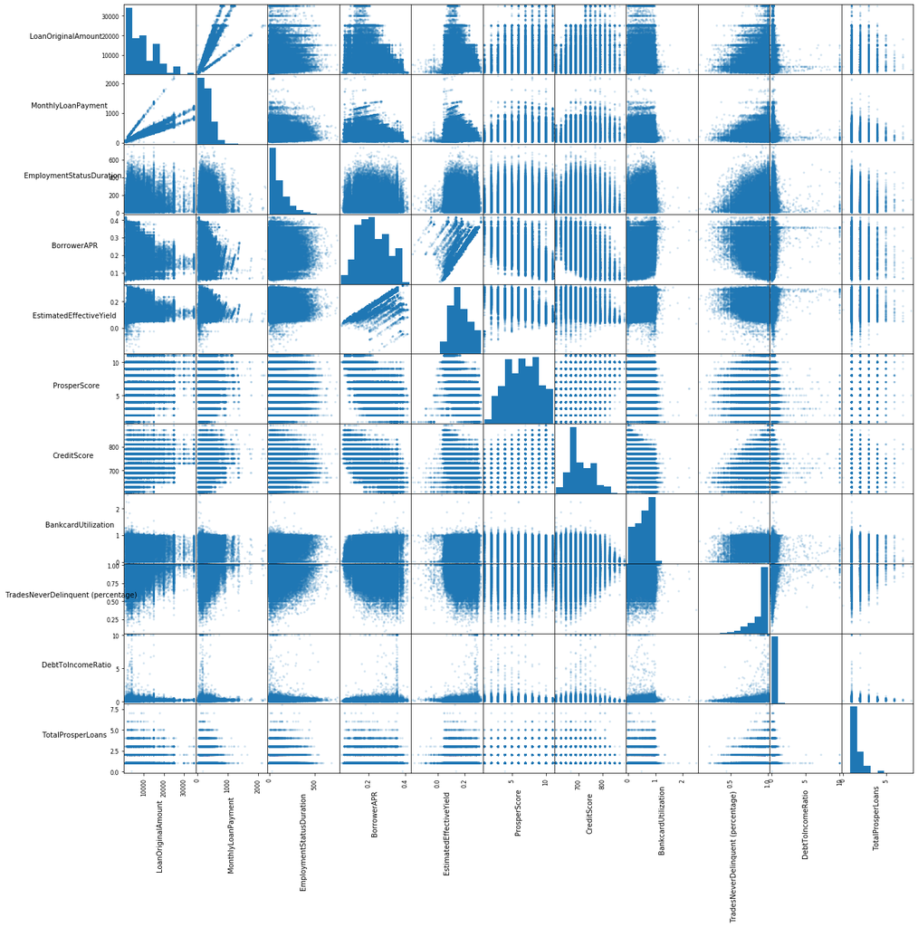

```python
## plot scatter matrix
axs= pd.plotting.scatter_matrix(dplot, alpha= .2, figsize=[20,20])
n= len(dplot.columns)
for x in range(n):
    for y in range(n):
        # to get the axis of subplots
        ax = axs[x, y]
        # to make x axis name vertical
        ax.xaxis.label.set_rotation(90)

        # to make y axis name horizontal
        ax.yaxis.label.set_rotation(0)

        # to make sure y axis names are outside the plot area
        ax.yaxis.labelpad = 50

plt.show()
```

back to top

Alright! Based on some potential relations that seem to have emerged from the graph above, we're going to focus our analysis on the following features:

**3.1. LoanOriginalAmount:**

We'll take a look at how the number of and the total amount of loans evolved along the years. That might give us some insight into how well the business is actually doing overall.

**3.2. LoanStatus:**

Then, we'll follow by taking a closer look at the loans which were defaulted against those which were completed. The aim is to find some insights and patterns on other features that may help predict whether a borrower may default or not. For simplicity, we are going to consider the features we believe are the ones most closely related *(EmploymentStatusDuration, IncomeRange, DebtToIncomeRatio, BankcardUtilization, LoanOriginalAmount, BorrowerAPR)*.

Ultimately, we could further refine this and use it to build a model to make predictions on how many of the current loans could be charged-off/defaulted. But that's outside the scope of this project, for now.

And, finally, we'll investigate how those 2 features of interest relate to each other and others.

Enough talking! We have lots to do, so let's dive right in.

back to top

### 3.1. LoanOriginalAmount

First of all, as an overall view of the business, we should answer the following question:

- **3.1.1\. What the distribution of number of loans issued and their amount look like?**

In order to answer this question let's take a look at the number of loans issued per year and per month.

#### Univariate Plots

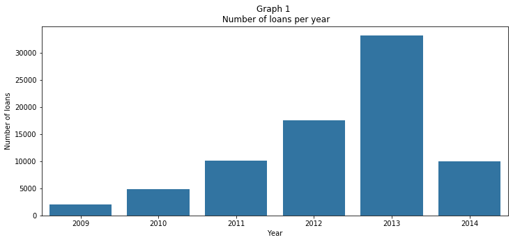

```python
## plot listings per year
plt.figure(figsize=[12, 5])
base_color = sb.color_palette()[0]
sb.countplot(data= df, x= df["ListingCreationDate"].dt.year,
             color= base_color)
plt.title('Graph 1 \n Number of loans per year')
plt.xlabel('Year')
plt.ylabel('Number of loans')
plt.show()
```

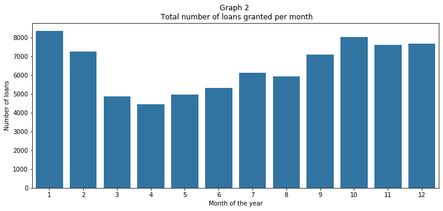

```python
## plot listings per month
plt.figure(figsize=[12, 5])
base_color = sb.color_palette()[0]
sb.countplot(data= df, x= df["ListingCreationDate"].dt.month,
             color= base_color)
plt.title('Graph 2 \n Total number of loans granted per month')
plt.xlabel('Month of the year')
plt.ylabel('Number of loans')
plt.show()
```

Graph 1 indicates an continued year-on-year growth on the number of loans issued. It is interesting to mention that 2014 has data only on the 1st quarter and, even then, it has already seen nearly the same amount of loans as the whole year of 2011.

Graph 2 seems to indicate that, throughout a 12-month period, loans tend to be issued in larger numbers during the Fall/Winter months (roughly through September up to January). Let's take a closer look and see if that's actually the case.

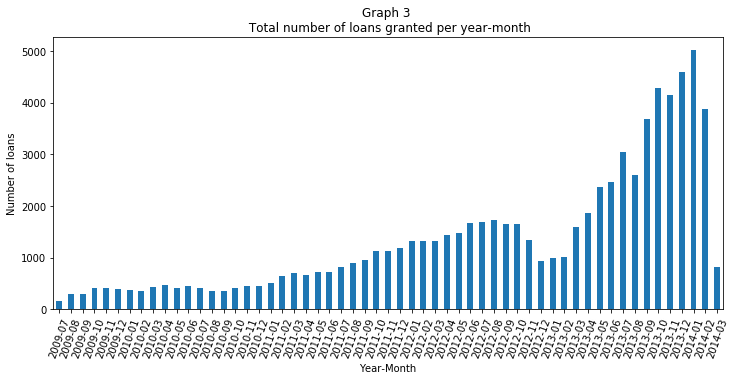

```python
## plot listings per year-month
per = df.ListingCreationDate.dt.to_period("M")
g= df.groupby(per)['ListingNumber'].nunique()
plt.figure(figsize=[12, 5])
g.plot(kind='bar')
plt.title('Graph 3 \n Total number of loans granted per year-month')
plt.xlabel('Year-Month')
plt.ylabel('Number of loans')
plt.xticks(rotation=70)
plt.show()
```

A closer look to Graph 3 indicates that, indeed, Prosper tends to issue more loans during the Fall/Winter months, except for the Winter of 2012/2013.

Given that the first three graphs indicate that loans tend to be issued following a certain pattern (larger numbers in the Fall/Winter months, lesser numbers in the Spring/Summer), let's take a look at the total amount lent per year and per month and see if that same patter emerges.

#### Bivariate Plots

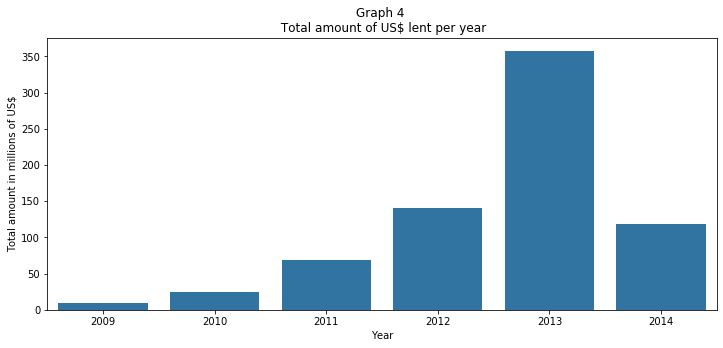

```python
## plot total amount lent per year
plt.figure(figsize=[12, 5])
base_color = sb.color_palette()[0]
sb.barplot(data= df, x= df.groupby(df["ListingCreationDate"].dt.year)["LoanOriginalAmount"].sum().index,
           y= df.groupby(df["ListingCreationDate"].dt.year)["LoanOriginalAmount"].sum().values,
           color= base_color)
tick_props = np.arange(0, 4e8, 5e7)
tick_names = [0, 50, 100, 150, 200, 250, 300, 350]
plt.yticks(tick_props, tick_names)
plt.title('Graph 4 \n Total amount of US$ lent per year')
plt.xlabel('Year')
plt.ylabel('Total amount in millions of US$')
plt.show()
```

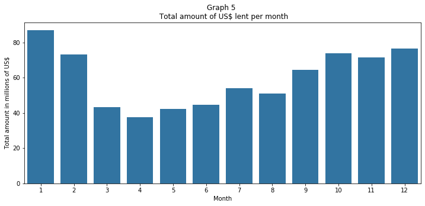

```python
## total amount lent per month
plt.figure(figsize=[12, 5])
base_color = sb.color_palette()[0]
sb.barplot(data= df, x= df.groupby(df["ListingCreationDate"].dt.month)["LoanOriginalAmount"].sum().index,
           y= df.groupby(df["ListingCreationDate"].dt.month)["LoanOriginalAmount"].sum().values,
           color= base_color)
tick_props = np.arange(0, 1e8, 2e7)
tick_names = np.arange(0, 100, 20)
plt.yticks(tick_props, tick_names)
plt.title('Graph 5 \n Total amount of US$ lent per month')
plt.xlabel('Month')
plt.ylabel('Total amount in millions of US$')
plt.show()
```

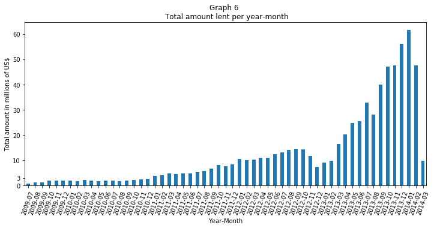

```python
## total amount lent per year-month
per = df.ListingCreationDate.dt.to_period("M")
g= df.groupby(per)['LoanOriginalAmount'].sum()
plt.figure(figsize=[12, 5])
g.plot(kind='bar')
tick_props = [0, 3e6, 1e7, 2e7, 3e7, 4e7, 5e7, 6e7]
tick_names = [0, 3, 10, 20, 30, 40, 50, 60]
plt.yticks(tick_props, tick_names)
plt.title('Graph 6 \n Total amount lent per year-month')
plt.xlabel('Year-Month')
plt.ylabel('Total amount in millions of US$')
plt.xticks(rotation=70)
plt.show()
```

back to top

As we can see from graphs 4 to 6, the pattern aforementioned holds. Also, it seems that the business is picking up pace after a short-lived dip in 2012.

It would, however, be interesting to see how well Prosper was doing in terms of share of the market. In other words, how well would Prosper be doing in comparison to its competitors.

Now, let's take a look into the following:

- **3.1.2\. How the LoanOriginalAmount and the MonthlyLoanPayment distributions looks like?**

#### Univariate plots

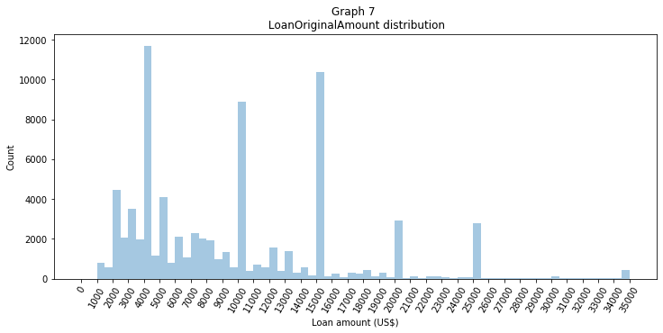

```python
## LoanOriginalAmount distribution
plt.figure(figsize=[12,5])
base_color = sb.color_palette()[0]
bin_size= 500
bins_e= np.arange(0, df.LoanOriginalAmount.max()+bin_size, bin_size)
sb.distplot(df['LoanOriginalAmount'], kde= False,
            bins= bins_e, color= base_color)
xtick_prop= np.arange(0, df.LoanOriginalAmount.max()+bin_size, bin_size*2)
xtick_name= list(xtick_prop)
plt.xticks(xtick_prop, xtick_name, rotation=60)
plt.title('Graph 7 \n LoanOriginalAmount distribution')
plt.xlabel('Loan amount (US$)')
plt.ylabel('Count')
plt.show()
```

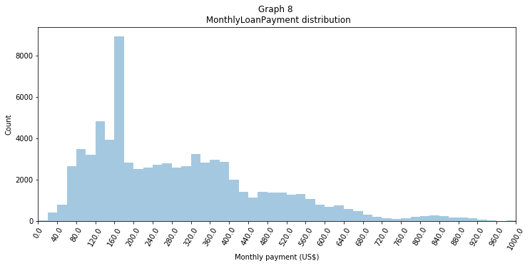

```python
## MonthlyLoanPayment distribution
plt.figure(figsize=[12,5])
base_color = sb.color_palette()[0]
bin_size= 20
bins_e= np.arange(0, df.MonthlyLoanPayment.max()+bin_size, bin_size)
sb.distplot(df['MonthlyLoanPayment'], kde= False,
            bins= bins_e, color= base_color)
xtick_prop= np.arange(0, df.MonthlyLoanPayment.max()+bin_size, bin_size*2)
xtick_name= list(xtick_prop)
plt.xticks(xtick_prop, xtick_name, rotation=60)
plt.title('Graph 8 \n MonthlyLoanPayment distribution')
plt.xlabel('Monthly payment (US$)')
plt.ylabel('Count')
plt.xlim(0, 1000)

plt.show()
```

Back to top

Based on Graphs 7 and 8, a couple of interesting insights here:

- Graph 7 indicates that there are 3 different loan amounts which are more commonly issued and they are around \$4000, \\$10000 and \$15000. Also, there are 4 others which are worthy mentioning: \\$2000, \$5000, \\$20000, \$25000.
- Graph 8, on its turn, shows that MonthlyLoanPayment follows a multimodal distribution with peaks around \$160-\\$200, \$360-\\$400 \$460-\\$560.

Ok. Interesting. Now, a follow up question arises:

- **3.1.3\. What the relationship between those 3 most common loan amounts and montlhy installment payments would look like?**

#### Bivariate plot

```python
## Selecting 3 most common loan amount
query= "LoanOriginalAmount >= 4000 and LoanOriginalAmount < 4500 or LoanOriginalAmount >= 10000 and LoanOriginalAmount < 10500 or LoanOriginalAmount >= 15000 and LoanOriginalAmount < 15500"
df1= df.query(query)
```

```python
## function to create new column
def selecter(row):
    if 4000 >= row < 4500:
        return '4k'
    elif 10000 >= row < 10500:
        return '10k'
    else:
        return '15k'
```

```python
## new column
df1['CommonLoanAmount']= df1.LoanOriginalAmount.apply(selecter)

## ordered categorical type
amount= ['4k', '10k', '15k']
cat_amount= pd.api.types.CategoricalDtype(ordered= True, categories= amount)
df1['CommonLoanAmount']= df1['CommonLoanAmount'].astype(cat_amount)
```

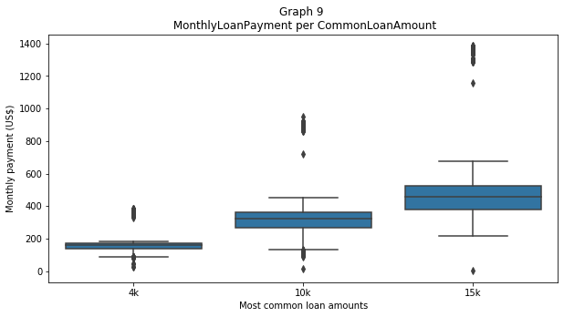

```python
## MonthlyLoanPayment for CommonLoanAmount
plt.figure(figsize=[10,5])
base_color = sb.color_palette()[0]
sb.boxplot(data= df1, x= 'CommonLoanAmount', y= 'MonthlyLoanPayment',
              color= base_color)
plt.title('Graph 9 \n MonthlyLoanPayment per CommonLoanAmount')
plt.ylabel('Monthly payment (US$)')
plt.xlabel('Most common loan amounts')
plt.show()
```

Back to top

As we can see from Graphs 8 and 9, the multimodal distribution of MonthlyLoanPayment seems to be related to the 3 most common loan amounts, as their monthly payment distribution, a part for a few outliers, match with those peaks in MonthlyLoanPayment. Also, it indicates that, on average, the larger the loan amount, larger the monthly payment.

Next, we should ask the following question:

- **3.1.4\. What the relationship between LoanOriginalAmount and MonthlyLoanPayment would look like?**

```python
## Sampling to avoid overplotting
df_subset= df.sample(n= 2500, replace= False, random_state=2021)
```

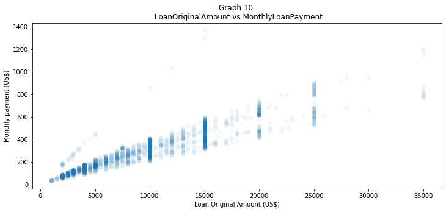

```python
## Scatter plot of LoanOriginalAmount vs MonthlyLoanPayment for current loans
plt.figure(figsize=[12,5])
sb.regplot(data= df_subset, y= 'MonthlyLoanPayment', x= 'LoanOriginalAmount',
           fit_reg= False, scatter_kws={'alpha':1/20}, y_jitter= 0.01)
plt.title('Graph 10 \n LoanOriginalAmount vs MonthlyLoanPayment')
plt.ylabel('Monthly payment (US$)')
plt.xlabel('Loan Original Amount (US$)')
plt.show()
```

Back to top

A quick look at Graph 10 ratifies our understanding that larger loans are closely related to larger monthly payments.

An interesting note is that the payments for larger and larger amounts tend to coalesce into 3 clearly distinct groups. A third variable in the dataset could be driving this phenomena and it's worthy of further investingation. One could guess that, the number of months into which one should pay back the whole amount would play a role in it, with longer terms being related to smaller monthly payments.

Next, we should answer the following question:

- **3.1.5\. Does the term of a loan influence the size of its monthly payments?**

#### Multivariate Plot

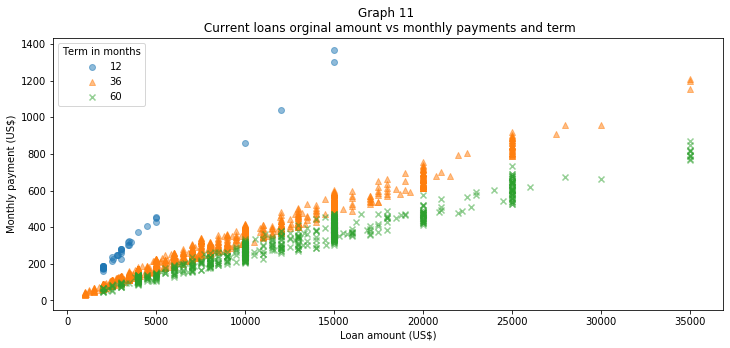

```python
## Plot current loans orginal amount vs monthly payments and term
term_markers = [['12', 'o'],
                ['36', '^'],
                ['60', 'x']]
plt.figure(figsize=[12,5])

for term, marker in term_markers:
    plot_data = df_subset.loc[df_subset['Term'] == term]
    sb.regplot(data= plot_data, y='MonthlyLoanPayment', x='LoanOriginalAmount',
           fit_reg= False, scatter_kws={'alpha':.5}, y_jitter= 0.01, marker= marker)
plt.ylabel('Monthly payment (US$)')
plt.xlabel('Loan amount (US$)')
plt.legend(['12', '36', '60'], title= 'Term in months')
plt.title('Graph 11 \n Current loans orginal amount vs monthly payments and term')
plt.show()
```

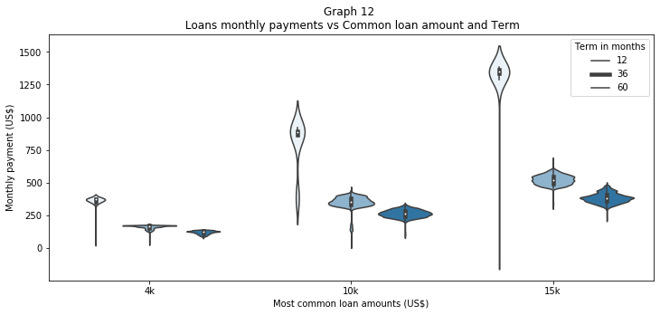

```python
## Plot Loans monthly payments vs Common loan amount and Term
plt.figure(figsize=[12,5])
base_color = sb.color_palette()[0]
sb.violinplot(data= df1, x='CommonLoanAmount', y= 'MonthlyLoanPayment',
              hue='Term',
              color=base_color)
plt.xlabel('Most common loan amounts (US$)')
plt.ylabel('Monthly payment (US$)')
plt.legend(['12', '36', '60'], title= 'Term in months')
plt.title('Graph 12 \n Loans monthly payments vs Common loan amount and Term')
plt.show()
```

Graphs 11 and 12 leave no room for doubt: the term of a loan plays a significant role in determining the size of its monthly payments, with shorter terms being associated with larger monthly installments.

Ok! So, let's summarize our finds on LoanOriginalAmount:

- Graphs 1 to 3 indicate an overall growth year-on-year. Also, that loans tend to be issued following a certain pattern (larger numbers in the Fall/Winter months, lesser numbers in the Spring/Summer). Furthermore, Graphs 4 to 6 confirm the aforementioned pattern. Also, it seems that the business is picking up pace after a short-lived dip in 2012.
  - It would, however, be interesting to see how well Prosper was doing in terms of market share. In other words, with the available data, we still don't know how well Prosper would be doing in comparison to its competitors.
- Graph 7 reveals the most commonly issued loan sizes: \$4000, \\$10000 and \$15000. Graph 8, on its turn, shows a multimodal distribution for MonthlyLoanPayment with peaks around \\$160-\$200, \\$360-\$400 \\$460-\$560. The relationship between those two is confirmed by Graph 9, the monthly payment distribution, a part for a few outliers, match with those peaks in MonthlyLoanPayment. Also, it indicates that, on average, the larger the loan amount, larger the monthly payment.
- Graph 10 confirms the understanding that larger loans are closely related to larger monthly payments. Furthermore, it indicates that payments tend to coalesce into 3 clearly distinct groups. This phenomena, as confirmed by Graphs 11 and 12, is driven by the loan term.

Back to top

### 3.2. LoanStatus

Great stuff! Now, for this portion of the analysis, we'll focus on distinguishing those loans which have been completed from those which have been defaulted. Nonetheless, first, let's take a quick look at the proportion of each LoanStatus from the total loans issued.

#### Univariate plot

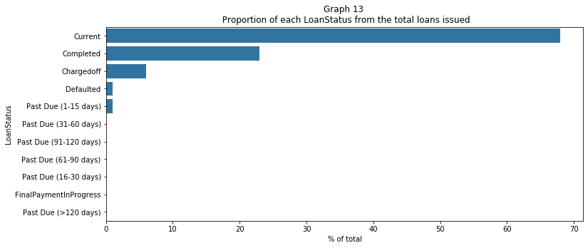

```python
## Getting proportions
g= ((df.LoanStatus.value_counts()/df_clean.LoanStatus.count())*100).round()

## plot
plt.figure(figsize=[12,5])
base_color = sb.color_palette()[0]
sb.barplot(data= df, y= g.index,
           x= g.values, color= base_color)
plt.title('Graph 13 \n Proportion of each LoanStatus from the total loans issued')
plt.xlabel('% of total')
plt.ylabel('LoanStatus')
plt.show()
```

Back to top

From Graph 13, we can see that the vast majority of loans are still current. But, again, at this point of the analysis, we are going to focus on the other LoanStatus values.

A quick note, though: this highlights the use of build a predictive model that could tell the portion of current loans that could be charged-off/defaulted. This could be helpful in preperating quarterly reports and, most importantly, setting aside sufficient funds for colaterals.

Now, that all being said, let's take a closer look at the following:

- **3.2.1\. How EmploymentStatusDuration, DebtToIncomeRatio, BankcardUtilization, IncomeRange are related to different LoanStatus?**

An important note must be made here: for simplicity sake's, we'll focus on completed vs defaulted loans, and we will also treat loans which have been charged-off in the same as if they had been defaulted.

For that, first, we need to select relevant LoanStatus values and create a new column.

#### Bivariate plots

```python
## function to create new 'defaulted' column
def selecter(row):
    if row == 'Completed':
        return row
    elif row == 'Chargedoff':
        return 'Defaulted'
    elif row == 'Defaulted':
        return 'Defaulted'
    else:
        return np.nan
```

```python
## Filtering for desired LoanStatus
query= "LoanStatus == 'Completed' or LoanStatus == 'Chargedoff' or LoanStatus == 'Defaulted'"
df_status= df_clean.query(query)
```

```python
## Create new column
df_status['Defaulted']= df_status.LoanStatus.apply(selecter)
```

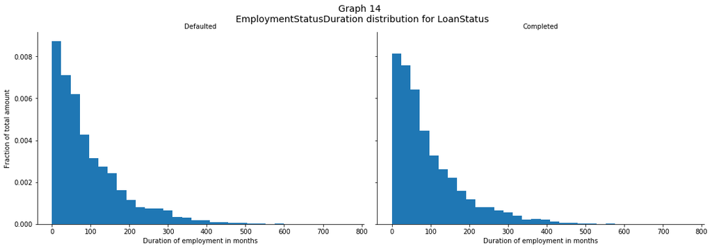

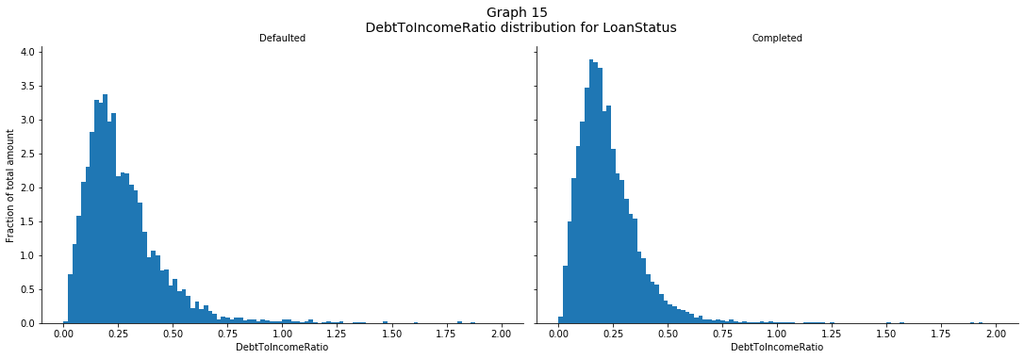

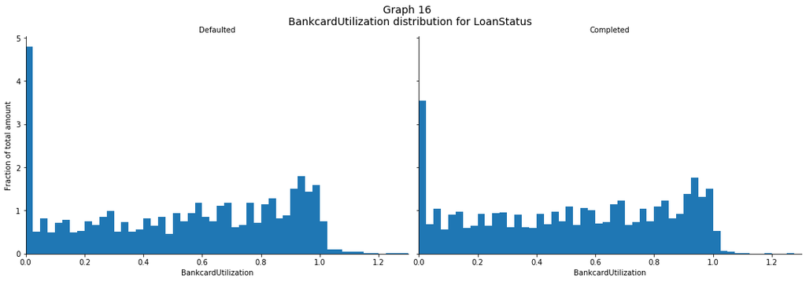

```python
## EmploymentStatusDuration distribution by LoanStatus
bin_size= 24
bins_e= np.arange(0, df_status.EmploymentStatusDuration.max()+bin_size, bin_size)
g= sb.FacetGrid(data= df_status, col= 'Defaulted', height= 5, aspect= 1.5)
g.map(plt.hist, 'EmploymentStatusDuration',
      bins= bins_e, density= True)
plt.suptitle('Graph 14 \n EmploymentStatusDuration distribution for LoanStatus',
             y= 1.05, fontsize=14)
g.set_titles('{col_name}')
g.set_xlabels('Duration of employment in months')
g.set_ylabels('Fraction of total amount')
plt.show()

## DebtToIncomeRatio distribution for LoanStatus
bin_size= 0.02
bins_e= np.arange(0, 2+bin_size, bin_size)
g= sb.FacetGrid(data= df_status, col= 'Defaulted', height= 5, aspect= 1.5)
g.map(plt.hist, 'DebtToIncomeRatio',
      bins= bins_e, density= True)
plt.suptitle('Graph 15 \n DebtToIncomeRatio distribution for LoanStatus',
             y= 1.05, fontsize=14)
g.set_titles('{col_name}')
g.set_xlabels('DebtToIncomeRatio')
g.set_ylabels('Fraction of total amount')
plt.show()

## BankcardUtilization distribution for LoanStatus
bin_size= 0.025
bins_e= np.arange(0, df_status.BankcardUtilization.max()+bin_size, bin_size)
g= sb.FacetGrid(data= df_status, col= 'Defaulted', height= 5, aspect= 1.5)
g.map(plt.hist, 'BankcardUtilization',
      bins= bins_e, density= True)
plt.xlim(0, 1.3)
plt.suptitle('Graph 16 \n BankcardUtilization distribution for LoanStatus',
             y= 1.05, fontsize=14)
g.set_titles('{col_name}')
g.set_xlabels('BankcardUtilization')
g.set_ylabels('Fraction of total amount')
plt.show()
```

Back to top

Graphs 14 to 16 indicate that *EmploymentStatusDuration*, *DebtToIncomeRatio*, and *BankcardUtilization* have really similar distributions regardless of LoanStatus.

This could indicative of the fact that someone defaulting or not on a loan may not be closely related to those variables, which is somewhat surprising. Common sense would suggest that the likelihood of someone defaulting should increase proportionally to that person's debt *(BankCardUtilization)* and/or debt ratio *(DebtToIncomeRation)*.

But, no!

So, Let's keep looking and check all these variables together and see if a pattern emerges.

#### Multivariate plot

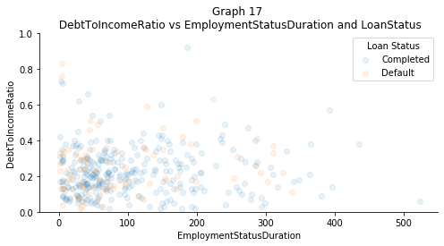

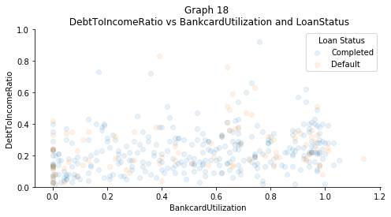

```python
## DebtToIncomeRatio vs EmploymentStatusDuration and LoanStatus
## DebtToIncomeRatio vs BankcardUtilization and LoanStatus
sample_size= 400
cols= ['EmploymentStatusDuration',
       'BankcardUtilization']
numbs= ['17', '18']
for col, numb in zip(cols, numbs):
    g = sb.FacetGrid(data = df_status.sample(sample_size, replace= False, random_state= 2021),
                     hue = 'Defaulted', height = 3.5, aspect= 2);
    g.map(sb.regplot, col,'DebtToIncomeRatio',
          scatter_kws={'alpha':1/10}, fit_reg= False)
    plt.ylim(0,1)
    plt.legend(['Completed', 'Default'], title= 'Loan Status')
    plt.title('Graph {} \n DebtToIncomeRatio vs {} and LoanStatus'.format(numb, col))
    plt.show()
```

Back to top

Given the lack of a clear pattern in Graphs 17 and 18 distinguishing completed from defaulted loans, it seems that the insight above on the lack of a close relationship between all these variables holds. In other words, it might be the case that, somewhat unexpectedly, these variables *(EmploymentStatusDurationf, DebtToIncomeRation, BankcardUtilization)* do not have a significant influence on someone defaulting on a loan.

That beeing said, let' move on to the next variable in our analysis: *IncomeRange*.

- **3.2.2\. How IncomeRange is related to different LoanStatus?**

#### Bivariate plot

```python
## Getting proportions
status_income= (df_status.groupby('Defaulted', observed= True)['IncomeRange']
               .value_counts(normalize= True)
               .rename('percentage')
               .mul(100)
               .reset_index())

income_status= (df_status.groupby('IncomeRange', observed= True)['Defaulted']
               .value_counts(normalize= True)
               .rename('percentage')
               .mul(100)
               .reset_index())
```

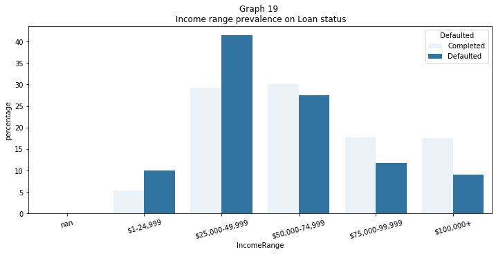

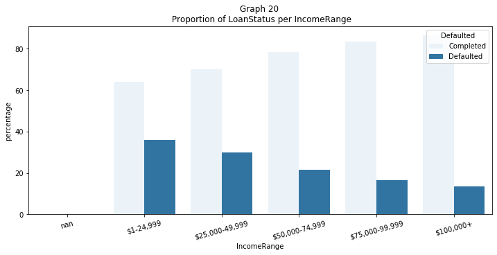

```python
## Loan status vs Income range
plt.figure(figsize=[12,5])
base_color = sb.color_palette()[0]
order_plot= [np.nan, '$1-24,999', '$25,000-49,999',
             '$50,000-74,999',  '$75,000-99,999', '$100,000+']
sb.barplot(data= status_income, x='IncomeRange', y= 'percentage',
              hue='Defaulted', color=base_color, order= order_plot)
plt.xticks(rotation=15)
plt.title('Graph 19 \n Income range prevalence on Loan status')
plt.show()

## Income range vs Loan status
plt.figure(figsize=[12,5])
base_color = sb.color_palette()[0]
order_plot= [np.nan, '$1-24,999', '$25,000-49,999',
             '$50,000-74,999',  '$75,000-99,999', '$100,000+']
sb.barplot(data= income_status, x='IncomeRange', y= 'percentage',
              hue='Defaulted', color=base_color, order= order_plot)
plt.xticks(rotation=15)
plt.title('Graph 20 \n Proportion of LoanStatus per IncomeRange')
plt.show()
```

Back to top

Looking at Graphs 19 and 20, we can see that as the income increases, the percentage of loans being defaulted decreases. This is somewhat expected as people with larger income, in general, would have more means to pay back their loans.

It is also worthy noting that the second tier of income (\$25000-\\$49999) is the one which contributes the most with defaulted loans. This, however, may be explained by the mere fact that most borrowers fall under this income range.

Also important to mention that, altough they contribute much less to the absolute number of defaulted loans, the first tier of income (< \$25000) is the one which, proportionally, defaults the most.

That being said, those earning under \$50000 per year deserve some further investigation.

Now, let's take a closer look at the following:

- **3.2.3\. How LoanOriginalAmount is related to different LoanStatus?**

Before we begin, a quick mention here that the *distribution for LoanOriginalAmount* has already been seen in Graph 7. Therefore, here, we will limit the scope to just that of completed vs defaulted loans.

That being said, taking into consideration the insights given by Graph 7 *(most common loan amounts around \$4000, \\$10000 and \$15000)*, and some intuition (*one would expect that larger loans should be related to higher rates of default* when paired with smaller income), let's take a look at the distribution of LoanOriginalAmount for LoanStatus completed and defaulted and see whether a pattern emerges.

#### Bivariate plot

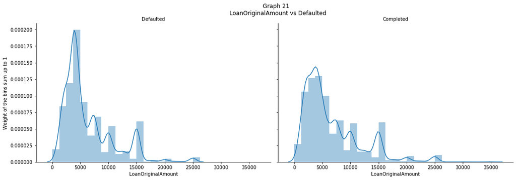

```python
## LoanOriginalAmount vs Defaulted
bin_size=1250
bins_e= np.arange(0, 35000+bin_size, bin_size)
g= sb.FacetGrid(data= df_status, col= 'Defaulted',
                height = 5, aspect= 1.5)
g.map(sb.distplot, 'LoanOriginalAmount', kde= True, norm_hist= True,
      bins= bins_e)
g.set_titles('{col_name}')
g.set_ylabels('Weight of the bins sum up to 1')
plt.suptitle('Graph 21 \n LoanOriginalAmount vs Defaulted',
            y= 1.05, x=.53)
plt.show()
```

Ok! First insight here. It appears that loans at around \$4000 are more likely then any other to be defaulted.

Again, this is somewhat counter-intuitive as we were expecting larger loans to do that. It certainly deserves some further investigation and, to do so, let's now see how those 3 most common loan amounts (\$4000, \\$10000 and \$15000) come into play here.

```python
## function to create new 'defaulted' column on df1_status
def selecter(row):
    if row == 'Completed':
        return False
    elif row == 'Chargedoff':
        return True
    elif row == 'Defaulted':
        return True
    else:
        return np.nan
```

```python
## df1 is dedicated to CommonLoanAmount
## Filtering for desired LoanStatus
query= "LoanStatus == 'Completed' or LoanStatus == 'Chargedoff' or LoanStatus == 'Defaulted'"
df1_status= df1.query(query)
```

```python
## Create new column
df1_status['Defaulted']= df1_status.LoanStatus.apply(selecter)
```

```python
## Getting proportions
LoanCounts= (df1_status.groupby('Defaulted')['CommonLoanAmount']
               .value_counts(normalize= True)
               .rename('percentage')
               .mul(100)
               .reset_index())
```

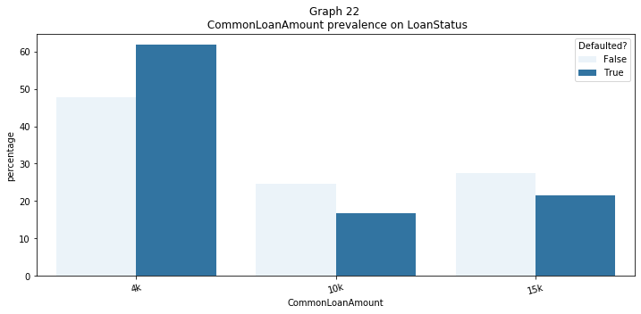

```python
## CommonLoanAmount vs LoanStatus
plt.figure(figsize=[12,5])
base_color = sb.color_palette()[0]
order_plot= ['4k', '10k', '15k']
sb.barplot(data= LoanCounts, x='CommonLoanAmount', y= 'percentage',
              hue='Defaulted', color=base_color, order= order_plot)
plt.xticks(rotation=15)
plt.legend(title= 'Defaulted?')
plt.title('Graph 22 \n CommonLoanAmount prevalence on LoanStatus')
plt.show()
```

Back to top

Cool. Graphs 21 and 22 point in the same unexpected direction: a spike on small loan amount (around 4k) being defaulted rather than on larger ones.

Taking into consideration the insights provided by Graphs 19 and 20 (people with smaller income tend to default more, particularly those with income under \$50000 per year), let's take a look on the relationship between the loan size and the income range of borrowers for the loans which have been defaulted. Given the evidence so far, one would guess that the majority of small loans would have been requested by people with the aforementioned income range.

```python
## Getting proportions
IncomeLoan= (df1_status.query("Defaulted == True")
            .groupby('CommonLoanAmount', observed= True)['IncomeRange']
            .value_counts(normalize= True)
            .rename('percentage')
            .mul(100)
            .reset_index())
```

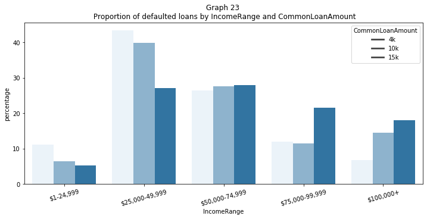

```python
## IncomeRange vs CommonLoanAmount for Defaulted loans
plt.figure(figsize=[12,5])
base_color = sb.color_palette()[0]
order_plot= ['$1-24,999', '$25,000-49,999', '$50,000-74,999', '$75,000-99,999', '$100,000+']
sb.barplot(data= IncomeLoan, x='IncomeRange', y= 'percentage',
              hue='CommonLoanAmount', color=base_color, order= order_plot)
plt.xticks(rotation=15)
plt.title('Graph 23 \n Proportion of defaulted loans by IncomeRange and CommonLoanAmount')
plt.legend(['4k', '10k', '15k'], title= 'CommonLoanAmount')
plt.show()
```

Back to top

- **3.2.4\. How BorrowerAPR is related to different LoanStatus?**

Ok! Similarly to *IncomeRange*, let's see if checking *BorrowerAPR* will unearth any patterns. Let's begin with its distribution.

```python
## quick investigation into min, mean, and max
df_status.BorrowerAPR.describe()
```

```
count    23026.000000
mean         0.246696
std          0.090751
min          0.045830
25%          0.171880
50%          0.254860
75%          0.329890
max          0.423950
Name: BorrowerAPR, dtype: float64
```

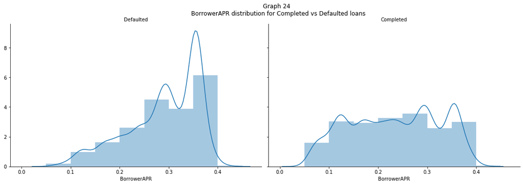

```python
## BorrowerAPR distribution
bin_size= 0.05
bins_e= np.arange(0, 0.45+bin_size, bin_size)
g= sb.FacetGrid(data= df_status, col= 'Defaulted',
                height = 5, aspect= 1.5)
g.map(sb.distplot, 'BorrowerAPR', kde= True, norm_hist= True,
      bins= bins_e)
g.set_titles('{col_name}')
plt.suptitle('Graph 24 \n BorrowerAPR distribution for Completed vs Defaulted loans',
             y= 1.05, x=.53)
plt.show()
```

Back to top

As one would expect, Graph 24 indicates that, as BorrowerAPR increases, also does the incidence of default.

Now, taking into account the insights provided by the LoanOriginalAmount analysis, let's see how they relate to BorrowerAPR and LoanStatus.

To achieve that, first, let's create a new column called *default_income*.

#### Multivariate plot

```python
## Create new df and add default_range column
df_income= df_status.copy()
```

```python
## function to create new 'defaulted' column on df1_status
default_income= ['$1-24,999','$25,000-49,999']

def selecter(row):
    if row in default_income:
        return '$1-49,999'
    else:
        return 'other'
```

```python
## apply selecter to create new column on df_income
df_income['default_income']= df_income['IncomeRange'].apply(selecter)
```

```python
## test
df_income['default_income'].describe()
```

```
count     23025
unique        2
top       other
freq      14143
Name: default_income, dtype: object
```

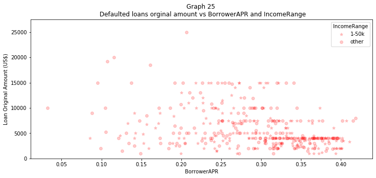

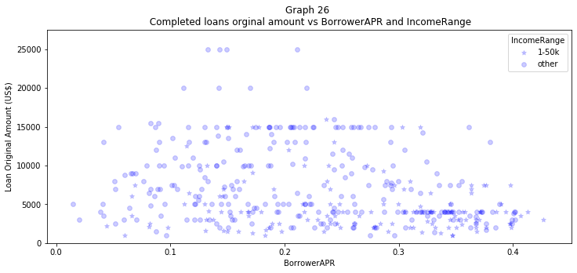

```python
## loans orginal amount vs BorrowerAPR and IncomeRange
income_markers = [['$1-49,999', '*'],
                  ['other', '8']]
status= ['Defaulted', 'Completed']
colors= ['red', 'blue']
numbs= ['25', '26']

for stat, color, numb in zip(status, colors, numbs):
    plt.figure(figsize=[12,5])
    for income, marker in income_markers:
        plot_data = (df_income[df_income['Defaulted']== stat]
                     .sample(n= 400, replace= True, random_state= 2021)
                     .loc[df_income['default_income'] == income])
        g= sb.regplot(data= plot_data, x='BorrowerAPR', y='LoanOriginalAmount', fit_reg= False,
                     marker= marker, color= color, scatter_kws={'alpha':.2},
                     x_jitter=.05, y_jitter=.05)
        plt.legend(['1-50k', 'other'], title= 'IncomeRange')
        plt.ylim(0, 27500)
        plt.xlabel('BorrowerAPR')
        plt.ylabel('Loan Original Amount (US$)')
        plt.title('Graph {} \n {} loans orginal amount vs BorrowerAPR and IncomeRange'.format(numb, stat))
    plt.show()
```

Back to top

back to top

## Conclusions

back to top

## References

[os.path - Common pathname manipulations](https://docs.python.org/3/library/os.path.html#module-os.path)

[NumPy Documentation](https://numpy.org/doc/)

[Pandas Documentation](https://pandas.pydata.org/docs/)

[Matplotlib Documentation](https://matplotlib.org/contents.html)

[Seaborn Documentation](https://seaborn.pydata.org)

[SQLite Documentation](https://docs.python.org/3/library/sqlite3.html)

[Nested lists using markdown](https://stackoverflow.com/questions/61540595/is-it-possible-to-make-a-nested-ordered-list-in-a-table-of-contents-in-jupyter-n)

[pandas.Series.map documentation](https://pandas.pydata.org/pandas-docs/stable/reference/api/pandas.Series.map.html#pandas-series-map)

[pandas.to_datetime documentation](https://pandas.pydata.org/pandas-docs/stable/reference/api/pandas.to_datetime.html#pandas-to-datetime)

[pandas.api.types.CategoricalDtype documentation](https://pandas.pydata.org/pandas-docs/version/0.23.4/generated/pandas.api.types.CategoricalDtype.html#pandas-api-types-categoricaldtype)

[pandas.DataFrame.agg documentation](https://pandas.pydata.org/pandas-docs/stable/reference/api/pandas.DataFrame.agg.html#pandas-dataframe-agg)

[Plot correlation matrix](https://stackoverflow.com/questions/29432629/plot-correlation-matrix-using-pandas)

[Making heatmap from pandas DataFrame](https://stackoverflow.com/questions/12286607/making-heatmap-from-pandas-dataframe)

[matplotlib.pyplot.matshow documentation](https://matplotlib.org/3.3.3/api/_as_gen/matplotlib.pyplot.matshow.html#matplotlib-pyplot-matshow)

[Matplotlib documentation plt.tick_params](https://matplotlib.org/3.1.1/api/_as_gen/matplotlib.pyplot.tick_params.html#matplotlib-pyplot-tick-params)

[Seaborn catplot documentation](https://seaborn.pydata.org/generated/seaborn.catplot.html#seaborn.catplot)

[Customizing annotation with Seaborn's FacetGrid](https://stackoverflow.com/a/31688467/13043172)

[using functions to avoid code repetition](https://scottc130.medium.com/using-functions-to-avoid-code-repetition-1fe4beff6d4d)

[Prosper](https://www.prosper.com)